# Stablecoins on Ethereum: USDC, USDT and DAI

Transfer sizes and gross transfer volumes

03 novembre 2026

# 1. Setup

### Observation period

We compare ERC-20 transfers during **two separate one-hour windows** on Ethereum mainnet: **1 October 2026, 12:00–13:00 UTC**, and **2 October 2026, 12:00–13:00 UTC**. Using the same clock hour on two dates makes it possible to compare the tokens without mixing in the intervening 23 hours.

The first hour was downloaded previously and is supplied as a CSV. For the second hour, the script checks the local cache and otherwise downloads the missing events from Etherscan. All three contracts are queried using the same start and end times on each date.

We count ERC-20 **Transfer events**, rather than Ethereum transactions. A single transaction can create several Transfer events, so the number of transfers may exceed the number of distinct transaction hashes.

### Token contracts

The contract address is used to query each stablecoin directly. The number of token decimals is needed when converting the raw amounts returned by Etherscan.

ERC-20 contracts used in the analysis

| Stablecoin | Ethereum contract address | Decimals |
| --- | --- | --- |
| USDC | 0xa0b86991c6218b36c1d19d4a2e9eb0ce3606eb48 | 6 |
| USDT | 0xdac17f958d2ee523a2206206994597c13d831ec7 | 6 |
| DAI | 0x6b175474e89094c44da98b954eedeac495271d0f | 18 |

### Etherscan connection and data preparation

The API key is read from `~/.Renviron` when data still need to be downloaded. The check below reports whether the variable is present; it does **not** validate the key with Etherscan, and the secret itself is never printed.

```r
# Controllo della chiave, senza mostrarne il valore.
api_key <- trimws(Sys.getenv("ETHERSCAN_API_KEY"))

if (nzchar(api_key)) {
  cat("SUCCESS: Etherscan API key found locally (not yet validated by the server).\n")
} else {
  cat("API key not configured: the second observation hour requires a valid key.\n")
}
```

```
## SUCCESS: Etherscan API key found locally (not yet validated by the server).
```

Etherscan API V2 (`tokentx`) retrieves the events for each contract. The code splits dense block ranges into smaller ranges to avoid silently losing results at the page-size limit. The cleaned CSV and per-token chunk cache avoid repeating successful requests.

USDC and USDT use six decimal places; DAI uses eighteen. The raw integer amount returned by Etherscan is converted into token units before any calculation. We retain separate events even if they share a transaction hash.

ERC-20 Transfer events by day and token

| day | token | transfer_events |
| --- | --- | --- |
| 2026-10-01 | USDC | 26405 |
| 2026-10-01 | USDT | 30361 |
| 2026-10-01 | DAI | 840 |
| 2026-10-02 | USDC | 28748 |
| 2026-10-02 | USDT | 30126 |
| 2026-10-02 | DAI | 772 |

# 2. Transfer sizes

The first question compares the amount moved in a single ERC-20 Transfer event. We report the median, mean and upper percentiles for **each token on each date**. Zero-value events remain in the summary but are excluded from charts with a logarithmic horizontal axis.

Transfer-size statistics by day (token units)

| day | token | transfers | zero_value_events | mean_size | median_size | p90 | p99 | max_size |
| --- | --- | --- | --- | --- | --- | --- | --- | --- |
| 2026-10-01 | USDC | 26405 | 875 | 61,943.77 | 200.00 | 10,000.00 | 546,110.37 | 106,098,942.99 |
| 2026-10-01 | USDT | 30361 | 1035 | 16,225.23 | 105.10 | 4,663.06 | 255,559.72 | 25,000,000.00 |
| 2026-10-01 | DAI | 840 | 10 | 58,643.49 | 1,270.00 | 200,022.15 | 500,054.79 | 719,791.56 |
| 2026-10-02 | USDC | 28748 | 481 | 52,822.10 | 252.13 | 13,157.37 | 626,684.66 | 200,000,000.00 |
| 2026-10-02 | USDT | 30126 | 436 | 23,199.26 | 137.97 | 5,556.24 | 299,133.66 | 26,699,029.71 |
| 2026-10-02 | DAI | 772 | 17 | 98,725.28 | 692.69 | 174,165.17 | 2,538,984.73 | 4,961,361.45 |

### Distribution of transfer sizes

The histograms show the positive transfer amounts separately for each stablecoin and observation day. The logarithmic amount axis gives small transfers and unusually large transfers room in the same chart.

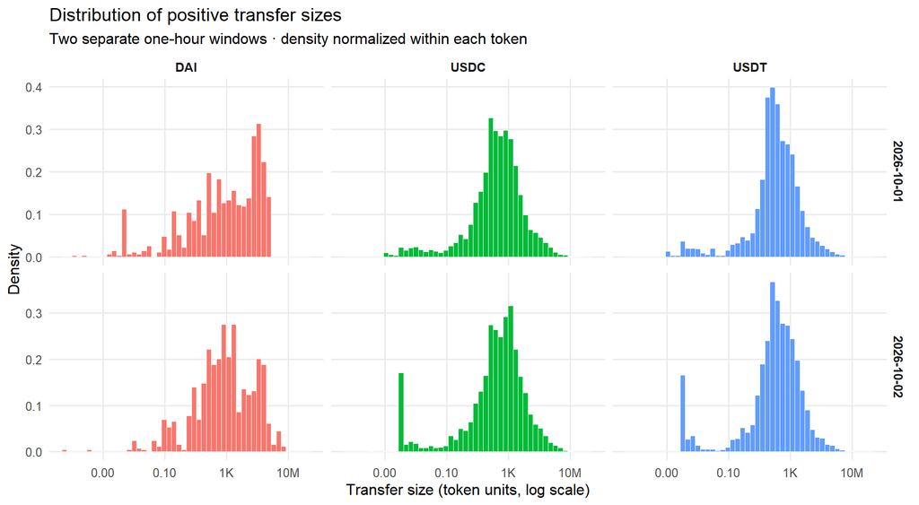

### Three stablecoins on the same graph — density curves

Here the three distributions are shown **as lines on the same axes**, with one panel per date. We estimate density from the base-10 logarithm of positive transfer amounts. This makes the curves comparable despite large differences in the number of Transfer events. Curve heights describe the relative distribution of transfer sizes, not the number of events or the amount of volume moved.

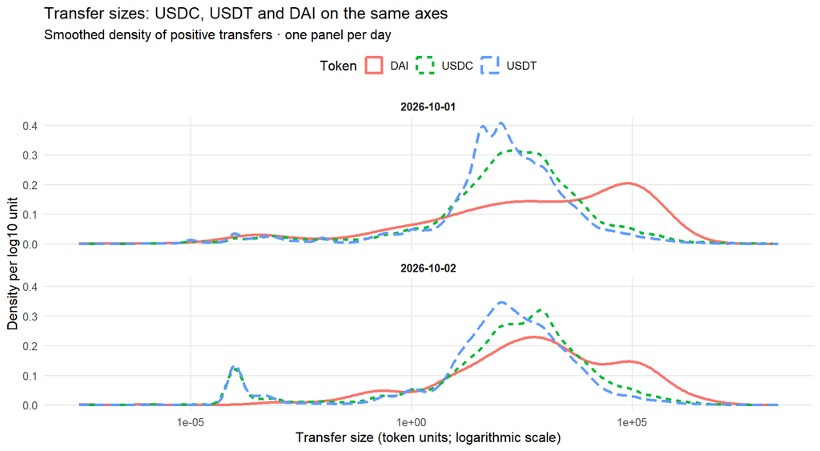

### Cumulative distribution

The cumulative curves show the share of positive transfers at or below each amount. They provide a second view of the comparison without relying on the smoothing used for the density curves.

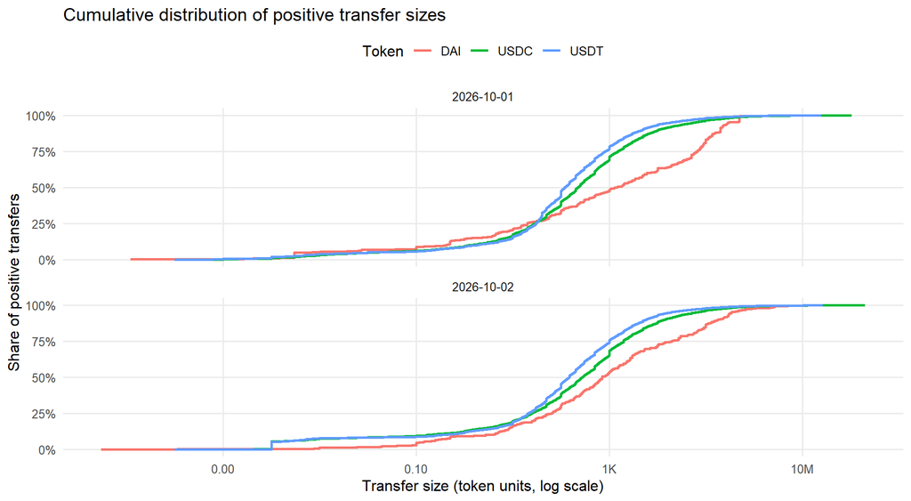

The size table and these three plots address the first challenge question. They should be read separately for each date, since each hour is an independent sample.

# 3. Transfer volumes

For the second question, we add the amounts of all Transfer events recorded for each token **within each hour**. The result is gross ERC-20 transfer volume measured in token units, not exchange trading volume. A separate count records how often transfers occur.

Transfer frequency and gross volume for each of the two hours

| Day (UTC) | Token | Transfer events | Distinct Ethereum transactions | Gross volume (token units) | Event share (%) | Volume share (%) |
| --- | --- | --- | --- | --- | --- | --- |
| 2026-10-01 | USDC | 26,405 | 15,894 | 1,635,625,149.66 | 45.84 | 75.11 |
| 2026-10-01 | USDT | 30,361 | 22,054 | 492,614,214.74 | 52.70 | 22.62 |
| 2026-10-01 | DAI | 840 | 366 | 49,260,530.03 | 1.46 | 2.26 |
| 2026-10-02 | USDC | 28,748 | 17,101 | 1,518,529,821.48 | 48.20 | 66.21 |
| 2026-10-02 | USDT | 30,126 | 22,505 | 698,900,795.62 | 50.51 | 30.47 |
| 2026-10-02 | DAI | 772 | 390 | 76,215,914.49 | 1.29 | 3.32 |

### Gross transfer volume

The two bars for each stablecoin correspond to the two dates. Each bar covers exactly one hour, allowing a direct comparison of nominal transfer volume across days.

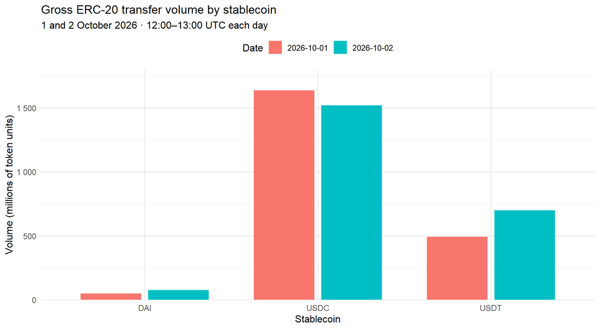

### Transfer frequency versus volume

The number of events and the sum of their amounts are displayed side by side. The two facets use different vertical scales because the quantities have different units.

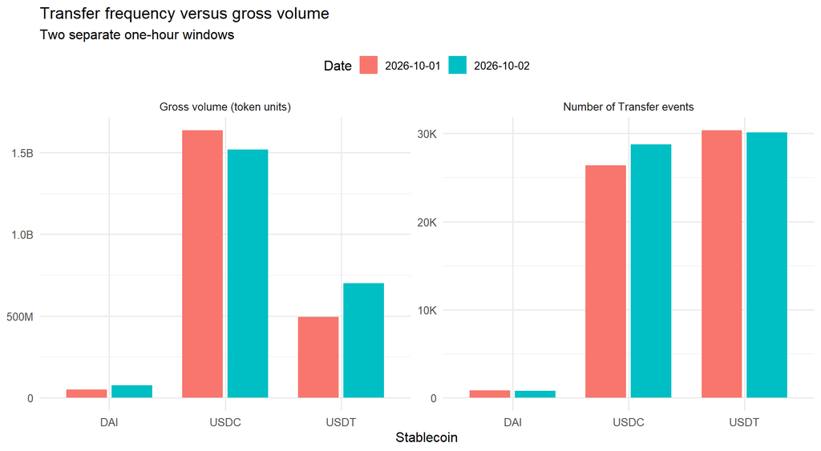

### Volume within each observation hour

The data are grouped into 10-minute intervals. The two days are shown in separate panels: we do **not** draw a line across the unobserved time between 1 October at 13:00 and 2 October at 12:00 UTC.

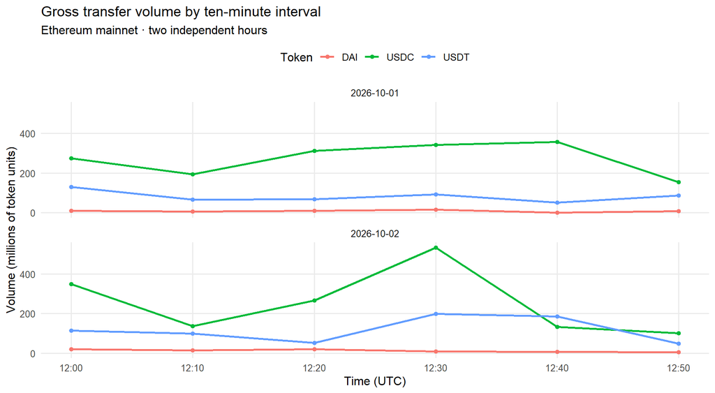

# 4. Conclusion

The two observations cover 12:00–13:00 UTC on 1 October and on 2 October 2026. The first question is answered by the size statistics and the comparative distributions; the second is answered by transfer counts and gross volumes, computed separately for each day.

**2026-10-01:** highest median transfer size: **DAI**; highest gross volume: **USDC**; most Transfer events: **USDT**.

**2026-10-02:** highest median transfer size: **DAI**; highest gross volume: **USDC**; most Transfer events: **USDT**.

These are observations from two selected hours, not daily totals. They measure on-chain ERC-20 Transfer events rather than trades on an exchange. The interpretation of differences between tokens and dates can be developed from the tables and figures above.